# Video Game Sales and Performance Analysis

## 4.1 Research Question 4 :

**Is there a statistically significant difference in mean sales for games with a rating of 7.5 or higher compared to those with a rating below 7.5? Can we determine a critical score that leads to higher sales?**

The primary goal of this research question is to assess the disparity in global sales between video games with a rating of 7.5 or higher and those with lower ratings.

Subsequently, We aim to determine a critical rating threshold at which the most substantial sales difference becomes evident.

The Hyoptheses are defined as follows :

- Null Hypothesis : There is no difference between the mean sales of both groups
- Altername Hypothesis : There is a non-zero difference between the mean sales of both groups

### 4.1.1 Threshold score of 7.5

```r
#-----------------------------------------------------------------------------------------------------------------
# SMART Q - Threshold Rating


rating_above <- subset(games_final, games_final$User_Score >= 7.5)
rating_below <- subset(games_final, games_final$User_Score < 7.5)

# Calculate the sample means
mean_sales_above <- mean(rating_above$Global_Sales)
mean_sales_below <- mean(rating_below$Global_Sales)

# Calculate the difference in means
diff_means <- mean_sales_above - mean_sales_below

# Perform a t-test for the two groups with unequal variances
t_test_result <- t.test(rating_above$Global_Sales, rating_below$Global_Sales, var.equal = FALSE)

cat("Mean difference is:", diff_means, "\n")
```

```
## Mean difference is: 0.09128393
```

```r
cat("P-Value for the T-Test:", t_test_result$p.value, "\n")
```

```
## P-Value for the T-Test: 5.346887e-20
```

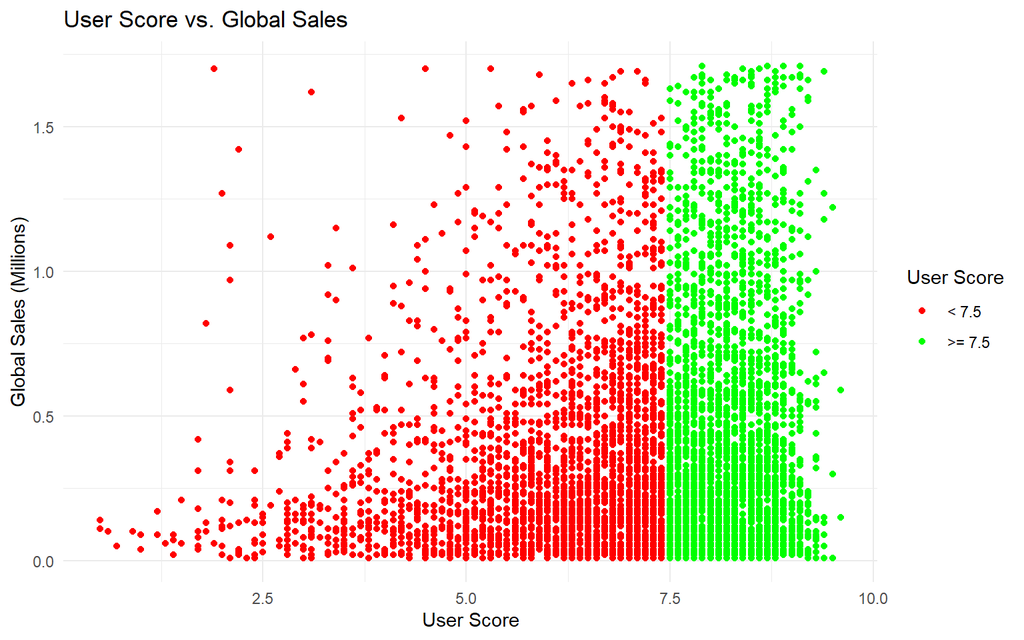

```r
ggplot(games_final, aes(x = User_Score, y = Global_Sales, color = User_Score >= 7.5)) +
  geom_point() +
  scale_color_manual(values = c("red", "green"),
                     breaks = c(FALSE, TRUE),
                     labels = c("< 7.5", ">= 7.5")) +
  labs(x = "User Score", y = "Global Sales (Millions)", title = "User Score vs. Global Sales") +
  guides(color = guide_legend(title = "User Score")) +
  theme_minimal()
```

As shown, the p value associated with the 2 sample t-test is low enough for us to reject the Null hypothesis

The difference in mean sales at the 7.5 rating threshold is 0.09 Million which is quite small. As the scatter plot illustrates, there is a lot of spread for games rated 7.5 or more, indicating a more multivariate complex relationship for the global sales.

### 4.1.2 Iterating to find the critical score

```r
#-----------------------------------------------------------------------------------------------------------------

#Iterating to find threshold

thresholds <- numeric()
diff_means_values <- numeric()
p_values <- numeric()

best_rating_threshold <- NA
best_diff_means <- -Inf
best_p_value <- 1  # Initialize with a value above 0.05


for (rating_threshold in seq(4.0, 8.5, by = 0.1)) {
  # Subset data for games with user scores above and below the threshold
  rating_above <- subset(games_final, games_final$User_Score >= rating_threshold)
  rating_below <- subset(games_final, games_final$User_Score < rating_threshold)

  # Calculate the sample means
  mean_sales_above <- mean(rating_above$Global_Sales)
  mean_sales_below <- mean(rating_below$Global_Sales)

  # Calculate the difference in means
  diff_means <- mean_sales_above - mean_sales_below

  # Perform a t-test for the two groups with unequal variances
  t_test_result <- t.test(rating_above$Global_Sales, rating_below$Global_Sales, var.equal = FALSE)

  # Store the results in vectors
  thresholds <- c(thresholds, rating_threshold)
  diff_means_values <- c(diff_means_values, diff_means)
  p_values <- c(p_values, t_test_result$p.value)

  # Check if the result is better than the current best result
  if (diff_means > best_diff_means && t_test_result$p.value < 0.05) {
    best_diff_means <- diff_means
    best_p_value <- t_test_result$p.value
    best_rating_threshold <- rating_threshold
  }
}

# Print the best result
cat("Best rating split with the highest mean difference and p-value below 0.05 is:", best_rating_threshold, "\n")
```

```
## Best rating split with the highest mean difference and p-value below 0.05 is: 4.1
```

```r
cat("Mean Difference in Sales:", best_diff_means, "\n")
```

```
## Mean Difference in Sales: 0.1728279
```

```r
cat("P-Value for the T-Test:", best_p_value, "\n")
```

```
## P-Value for the T-Test: 1.321208e-20
```

As shown, the user score of 4.1 produces the highest difference in mean global sales between both groups at 0.17 Million copies. The p value associated with the test is enough to reject the Null Hypothesis.

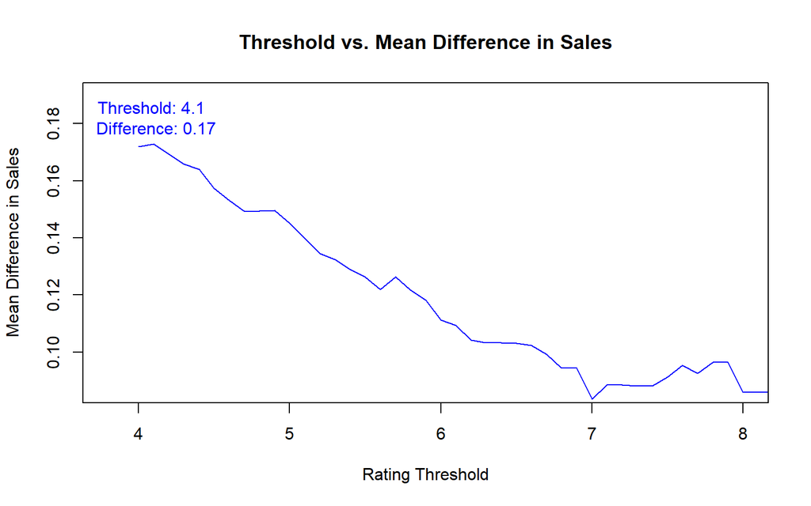

```r
#-- Visually showing the result
plot(
  thresholds,
  diff_means_values,
  type = "l",
  col = "blue",
  xlab = "Rating Threshold",
  ylab = "Mean Difference in Sales",
  main = "Threshold vs. Mean Difference in Sales",
  xlim = c(3.8, 8),
  ylim = c(max(diff_means_values) * 0.5, max(diff_means_values) * 1.1)
)

# Label points with maximum mean difference
max_diff_idx <- which.max(diff_means_values)
text(
  thresholds[max_diff_idx],
  diff_means_values[max_diff_idx],
  labels = paste("Threshold:", thresholds[max_diff_idx], "\n Difference:", round(diff_means_values[max_diff_idx], 2)),
  pos = 3,
  col = "blue"
)
```

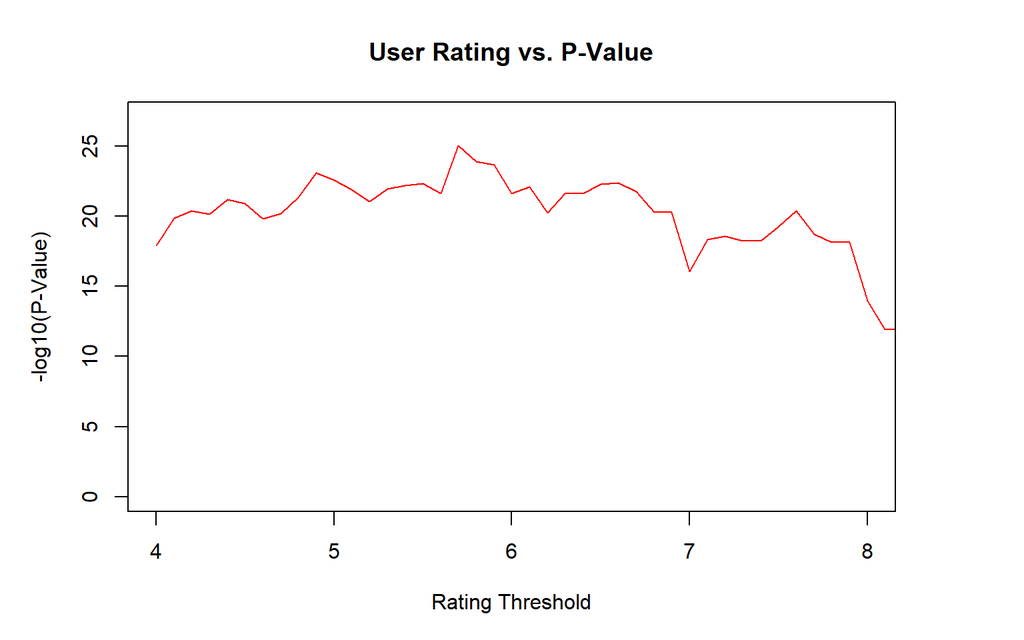

```r
# Create a new plot for p-value vs. rating
par(mar = c(5, 5, 4, 5))  # Adjust margin for labels
plot(
  thresholds,
  -log10(p_values),
  type = "l",
  col = "red",
  xlab = "Rating Threshold",
  ylab = "-log10(P-Value)",
  main = "User Rating vs. P-Value",
  xlim = c(4, 8),
  ylim = c(0, max(-log10(p_values)) + 2)
)
```

The p values are of the order of magnitude of -10 or lower indicating that the results are statistically significant across the board

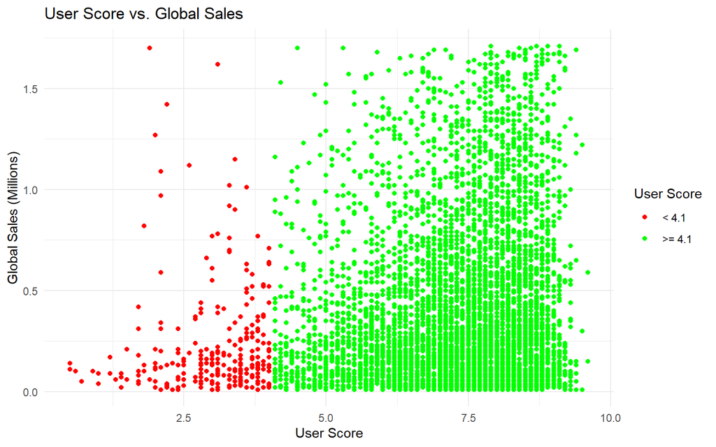

```r
ggplot(games_final, aes(x = User_Score, y = Global_Sales, color = User_Score >= 4.1)) +
  geom_point() +
  scale_color_manual(values = c("red", "green"),
                     breaks = c(FALSE, TRUE),
                     labels = c("< 4.1", ">= 4.1")) +
  labs(x = "User Score", y = "Global Sales (Millions)", title = "User Score vs. Global Sales") +
  guides(color = guide_legend(title = "User Score")) +
  theme_minimal()
```

Once again, the scatter chart illustrates the complex relationship between user score and global sales. For lower values of user score such as 4.1, we can see clear trends and a positive correlation. However, this behavior becomes diluted for higher user scores

### 4.1.3 Bonferroni Correction

The Bonferroni test is a multiple-comparison correction used when several dependent or independent statistical tests are being performed simultaneously. The reason is that while a given alpha value may be appropriate for each individual comparison, it is not appropriate for the set of all comparisons. We must check if the p value is less than alpha (0.05) divided by the number of tests performed.

In the case of our tests, we are testing multiple user scores to determine whether the differences in the mean sales between the groups is statistically significant. However, given our p values are of the order -10 and lower, adjusting alpha with the Bonferroni correction would still yield very statistically significant results